# Analiza danych - zadanie 2/ Bank additional

Michał Krawczuk

2022-10-17

# Cele i mierniki

## Biznesowy

Zdefiniowanie grupy docelowych klientów, którzy chętniej podejmują pozytywną decyzję o założeniu lokaty

## Analityczny

Znalezienie korelacji w danych historycznych, która pozwoli na łatwiejszą identyfikację osób o większej skłonności do założenia lokaty

## KPI

Korelacja między zmienną objaśniającą, a założeniem konta bankowego Procentowa dystrybucja poszczególnych czynników

# Opis danych

## Deskryptywny

|  | age | job | marital | education | default | housing | loan | contact | month | day_of_week | duration | campaign | pdays | previous | poutcome | emp.var.rate | cons.price.idx | cons.conf.idx | euribor3m | nr.employed | y |
| --- | --- | --- | --- | --- | --- | --- | --- | --- | --- | --- | --- | --- | --- | --- | --- | --- | --- | --- | --- | --- | --- |
| 1 | 30 | blue-collar | married | basic.9y | no | yes | no | cellular | may | fri | 487 | 2 | non | 0 | nonexistent | -1.8 | 92.893 | -46.2 | 1.313 | 5099.1 | 0 |
| 2 | 39 | services | single | high.school | no | no | no | telephone | may | fri | 346 | 4 | non | 0 | nonexistent | 1.1 | 93.994 | -36.4 | 4.855 | 5191 | 0 |
| 3 | 25 | services | married | high.school | no | yes | no | telephone | jun | wed | 227 | 1 | non | 0 | nonexistent | 1.4 | 94.465 | -41.8 | 4.962 | 5228.1 | 0 |
| 4 | 38 | services | married | basic.9y | no | unknown | unknown | telephone | jun | fri | 17 | 3 | non | 0 | nonexistent | 1.4 | 94.465 | -41.8 | 4.959 | 5228.1 | 0 |
| 5 | 47 | admin. | married | university.degree | no | yes | no | cellular | nov | mon | 58 | 1 | non | 0 | nonexistent | -0.1 | 93.2 | -42 | 4.191 | 5195.8 | 0 |
| 6 | 32 | services | single | university.degree | no | no | no | cellular | sep | thu | 128 | 3 | non | 2 | failure | -1.1 | 94.199 | -37.5 | 0.884 | 4963.6 | 0 |
| 7 | 32 | admin. | single | university.degree | no | yes | no | cellular | sep | mon | 290 | 4 | non | 0 | nonexistent | -1.1 | 94.199 | -37.5 | 0.879 | 4963.6 | 0 |
| 8 | 41 | entrepreneur | married | university.degree | unknown | yes | no | cellular | nov | mon | 44 | 2 | non | 0 | nonexistent | -0.1 | 93.2 | -42 | 4.191 | 5195.8 | 0 |
| 9 | 31 | services | divorced | professional.course | no | no | no | cellular | nov | tue | 68 | 1 | non | 1 | failure | -0.1 | 93.2 | -42 | 4.153 | 5195.8 | 0 |
| 10 | 35 | blue-collar | married | basic.9y | unknown | no | no | telephone | may | thu | 170 | 1 | non | 0 | nonexistent | 1.1 | 93.994 | -36.4 | 4.855 | 5191 | 0 |

[output cut: 4109 more lines]

```
## Rows: 4,119
## Columns: 21
## $ age            <dbl> 30, 39, 25, 38, 47, 32, 32, 41, 31, 35, 25, 36, 36, 47,~
## $ job            <chr> "blue-collar", "services", "services", "services", "adm~
## $ marital        <chr> "married", "single", "married", "married", "married", "~
## $ education      <chr> "basic.9y", "high.school", "high.school", "basic.9y", "~
## $ default        <chr> "no", "no", "no", "no", "no", "no", "no", "unknown", "n~
## $ housing        <chr> "yes", "no", "yes", "unknown", "yes", "no", "yes", "yes~
## $ loan           <chr> "no", "no", "no", "unknown", "no", "no", "no", "no", "n~
## $ contact        <chr> "cellular", "telephone", "telephone", "telephone", "cel~
## $ month          <ord> may, may, jun, jun, nov, sep, sep, nov, nov, may, jul, ~
## $ day_of_week    <ord> fri, fri, wed, fri, mon, thu, mon, mon, tue, thu, thu, ~
## $ duration       <dbl> 487, 346, 227, 17, 58, 128, 290, 44, 68, 170, 301, 148,~
## $ campaign       <dbl> 2, 4, 1, 3, 1, 3, 4, 2, 1, 1, 1, 1, 2, 2, 2, 2, 6, 4, 2~
## $ pdays          <chr> "non", "non", "non", "non", "non", "non", "non", "non",~
## $ previous       <dbl> 0, 0, 0, 0, 0, 2, 0, 0, 1, 0, 0, 0, 0, 0, 0, 0, 0, 0, 0~
## $ poutcome       <chr> "nonexistent", "nonexistent", "nonexistent", "nonexiste~
## $ emp.var.rate   <dbl> -1.8, 1.1, 1.4, 1.4, -0.1, -1.1, -1.1, -0.1, -0.1, 1.1,~
## $ cons.price.idx <dbl> 92.893, 93.994, 94.465, 94.465, 93.200, 94.199, 94.199,~
## $ cons.conf.idx  <dbl> -46.2, -36.4, -41.8, -41.8, -42.0, -37.5, -37.5, -42.0,~
## $ euribor3m      <dbl> 1.313, 4.855, 4.962, 4.959, 4.191, 0.884, 0.879, 4.191,~
## $ nr.employed    <dbl> 5099.1, 5191.0, 5228.1, 5228.1, 5195.8, 4963.6, 4963.6,~
## $ y              <dbl> 0, 0, 0, 0, 0, 0, 0, 0, 0, 0, 0, 0, 0, 0, 0, 0, 0, 0, 0~
```

## Implicite

- przedziay wiekowe (np. sekwencja co 15 lat)
- data (wymaga przyjęcia dodatkowych założeń)

```
## Rows: 4,119
## Columns: 1
## $ age <fct> "(18,33]", "(33,48]", "(18,33]", "(33,48]", "(33,48]", "(18,33]", ~
```

## Wstępna analiza

Przegląd typów zmiennych oraz ich przykładowych wartości

### Data Frame Summary

#### bank

**Dimensions:** 4119 x 21  
**Duplicates:** 0

No

Variable

Stats / Values

Freqs (% of Valid)

Graph

Missing

age  
[factor]

1. (18,33]  
2. (33,48]  
3. (48,63]  
4. (63,78]  
5. (78,93]

1302 (31.6%)  
1897 (46.1%)  
854 (20.7%)  
50 ( 1.2%)  
13 ( 0.3%)

3  
(0.1%)

2

job  
[character]

1. admin.  
2. blue-collar  
3. technician  
4. services  
5. management  
6. retired  
7. self-employed  
8. entrepreneur  
9. unemployed  
10. housemaid  
[ 2 others ]

1012 (24.6%)  
884 (21.5%)  
691 (16.8%)  
393 ( 9.5%)  
324 ( 7.9%)  
166 ( 4.0%)  
159 ( 3.9%)  
148 ( 3.6%)  
111 ( 2.7%)  
110 ( 2.7%)  
121 ( 2.9%)

0  
(0.0%)

3

marital  
[character]

1. divorced  
2. married  
3. single  
4. unknown

446 (10.8%)  
2509 (60.9%)  
1153 (28.0%)  
11 ( 0.3%)

0  
(0.0%)

4

education  
[character]

1. basic.4y  
2. basic.6y  
3. basic.9y  
4. high.school  
5. illiterate  
6. professional.course  
7. university.degree  
8. unknown

429 (10.4%)  
228 ( 5.5%)  
574 (13.9%)  
921 (22.4%)  
1 ( 0.0%)  
535 (13.0%)  
1264 (30.7%)  
167 ( 4.1%)

0  
(0.0%)

5

default  
[character]

1. no  
2. unknown  
3. yes

3315 (80.5%)  
803 (19.5%)  
1 ( 0.0%)

0  
(0.0%)

6

housing  
[character]

1. no  
2. unknown  
3. yes

1839 (44.6%)  
105 ( 2.5%)  
2175 (52.8%)

0  
(0.0%)

7

loan  
[character]

1. no  
2. unknown  
3. yes

3349 (81.3%)  
105 ( 2.5%)  
665 (16.1%)

0  
(0.0%)

8

contact  
[character]

1. cellular  
2. telephone

2652 (64.4%)  
1467 (35.6%)

0  
(0.0%)

9

month  
[ordered, factor]

0 ( 0.0%)  
0 ( 0.0%)  
48 ( 1.2%)  
215 ( 5.2%)  
1378 (33.5%)  
530 (12.9%)  
711 (17.3%)  
636 (15.4%)  
69 ( 1.7%)  
64 ( 1.6%)  
468 (11.4%)

0  
(0.0%)

10

day_of_week  
[ordered, factor]

1. mon  
2. tue  
3. wed  
4. thu  
5. fri  
6. sat  
7. sun

855 (20.8%)  
841 (20.4%)  
795 (19.3%)  
860 (20.9%)  
768 (18.6%)  
0 ( 0.0%)  
0 ( 0.0%)

0  
(0.0%)

11

duration  
[numeric]

Mean (sd) : 256.8 (254.7)  
min < med < max:  
0 < 181 < 3643  
IQR (CV) : 214 (1)

828 distinct values

0  
(0.0%)

12

campaign  
[numeric]

Mean (sd) : 2.5 (2.6)  
min < med < max:  
1 < 2 < 35  
IQR (CV) : 2 (1)

25 distinct values

0  
(0.0%)

13

pdays  
[character]

1. non  
2. 3  
3. 6  
4. 4  
5. 7  
6. 10  
7. 12  
8. 2  
9. 5  
10. 1  
[ 11 others ]

3959 (96.1%)  
52 ( 1.3%)  
42 ( 1.0%)  
14 ( 0.3%)  
10 ( 0.2%)  
8 ( 0.2%)  
5 ( 0.1%)  
4 ( 0.1%)  
4 ( 0.1%)  
3 ( 0.1%)  
18 ( 0.4%)

[figure not shown]

0  
(0.0%)

14

previous  
[numeric]

Mean (sd) : 0.2 (0.5)  
min < med < max:  
0 < 0 < 6  
IQR (CV) : 0 (2.8)

0 : 3523 (85.5%)  
1 : 475 (11.5%)  
2 : 78 ( 1.9%)  
3 : 25 ( 0.6%)  
4 : 14 ( 0.3%)  
5 : 2 ( 0.0%)  
6 : 2 ( 0.0%)

0  
(0.0%)

15

poutcome  
[character]

1. failure  
2. nonexistent  
3. success

454 (11.0%)  
3523 (85.5%)  
142 ( 3.4%)

0  
(0.0%)

16

emp.var.rate  
[numeric]

Mean (sd) : 0.1 (1.6)  
min < med < max:  
-3.4 < 1.1 < 1.4  
IQR (CV) : 3.2 (18.4)

-3.40 : 104 ( 2.5%)  
-3.00 : 21 ( 0.5%)  
-2.90 : 164 ( 4.0%)  
-1.80 : 883 (21.4%)  
-1.70 : 87 ( 2.1%)  
-1.10 : 83 ( 2.0%)  
-0.20 : 1 ( 0.0%)  
-0.10 : 392 ( 9.5%)  
1.10 : 758 (18.4%)  
1.40 : 1626 (39.5%)

0  
(0.0%)

17

cons.price.idx  
[numeric]

Mean (sd) : 93.6 (0.6)  
min < med < max:  
92.2 < 93.7 < 94.8  
IQR (CV) : 0.9 (0)

26 distinct values

0  
(0.0%)

18

cons.conf.idx  
[numeric]

Mean (sd) : -40.5 (4.6)  
min < med < max:  
-50.8 < -41.8 < -26.9  
IQR (CV) : 6.3 (-0.1)

26 distinct values

0  
(0.0%)

19

euribor3m  
[numeric]

Mean (sd) : 3.6 (1.7)  
min < med < max:  
0.6 < 4.9 < 5  
IQR (CV) : 3.6 (0.5)

234 distinct values

0  
(0.0%)

20

nr.employed  
[numeric]

Mean (sd) : 5166.5 (73.7)  
min < med < max:  
4963.6 < 5191 < 5228.1  
IQR (CV) : 129 (0)

11 distinct values

0  
(0.0%)

21

y  
[numeric]

Min : 0  
Mean : 0.1  
Max : 1

0 : 3668 (89.1%)  
1 : 451 (10.9%)

0  
(0.0%)

## Szukanie korelacji.

Pozwoli to na znalezienie zmiennych, które najlepiej nadają się do profilowania najbardziej wartosciowych (pod względem prawdopodobieństwa na założenie lokaty) klientów

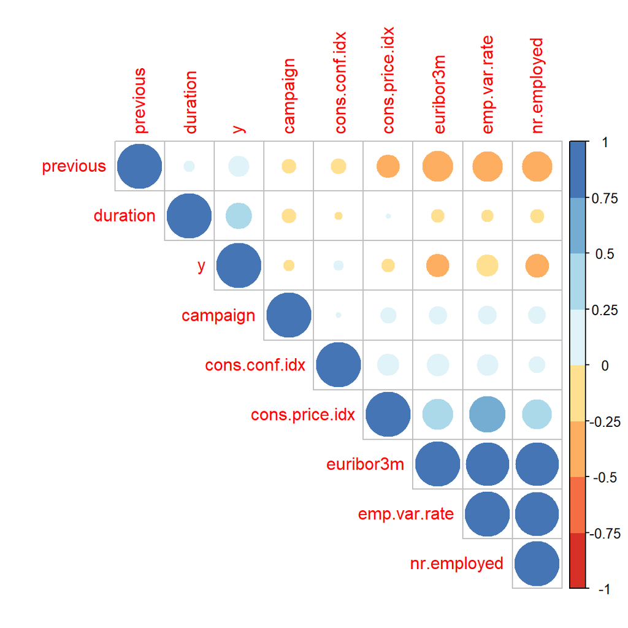